# `ggspectra` 0.1.3 User Guide

Pedro J. Aphalo

2016-01-10

## Introduction

Package `ggspectra` extends `ggplot2` with stats, geoms and annotations suitable for light spectra. It also defines `ggplot()` and `plot()` methods specialized for the classes defined in package `photobiology` for storing different types of spectral data.

The new elements can be freely combined with methods and functions defined in packages `ggplot2`, `scales` and `cowplot`.

Although the package uses internally `ggplot2`, `photobiology` and `photobiologyWavebands` it does not re-export these packages, which need to loaded if used.

```r
library(ggplot2)
library(photobiology)
library(photobiologyWavebands)
library(ggspectra)
```

We bind two spectra, to later on demonstrate grouping.

```r
two_suns.spct <- rbindspct(list(sun1 = sun.spct, sun2 = sun.spct * 2))
```

We change the default theme.

```r
theme_set(theme_bw())
```

## ggplot() methods for spectra

The only difference between these specializations and the base `ggplot()` method is that the aesthetics for $x$ and $y$ have suitable defaults. These are just defaults, so if needed they can still be supplied with a `mapping` argument with an user-defined `aes()`.

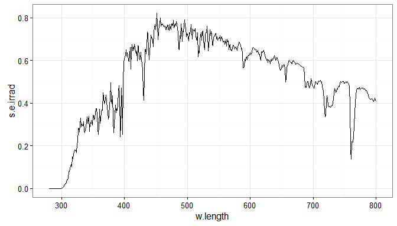

```r
ggplot(sun.spct) + geom_line()
```

It is possible to the defaults by means of `+` and `aes()` as shown below.

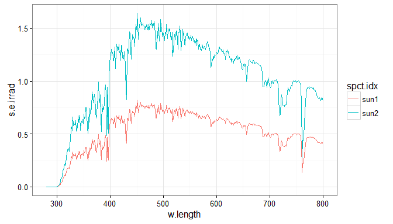

```r
ggplot(two_suns.spct) + aes(color = spct.idx) + geom_line()
```

If a mapping is supplied directly through `ggplot`, $x$ and $y$ should be included.

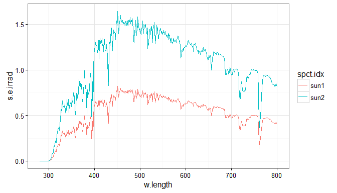

```r
ggplot(two_suns.spct, aes(w.length, s.e.irrad, color = spct.idx)) + geom_line()
```

In the case of `ggplot.source_spct()` an additional parameter allows setting the type of units to use in the plot. This not only sets a suitable `aes()` for $y$ but also if needed converts the spectral data. The two possible values are `"energy"` and `"photon"` and the default, depends on option `photobiology.radiation.unit`.

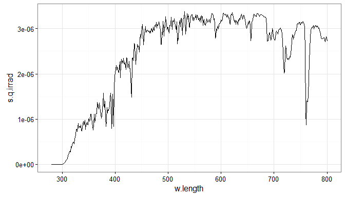

```r
ggplot(sun.spct, unit.out = "photon") + geom_line()
```

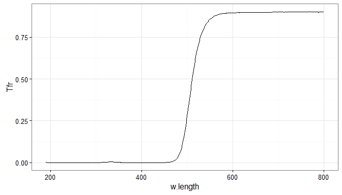

```r
ggplot(yellow_gel.spct) + geom_line()
```

In the case of `ggplot.filter_spct()` the additional parameter is called `plot.qty` and allows choosing between `"transmittance"` and `"absorbance"`.

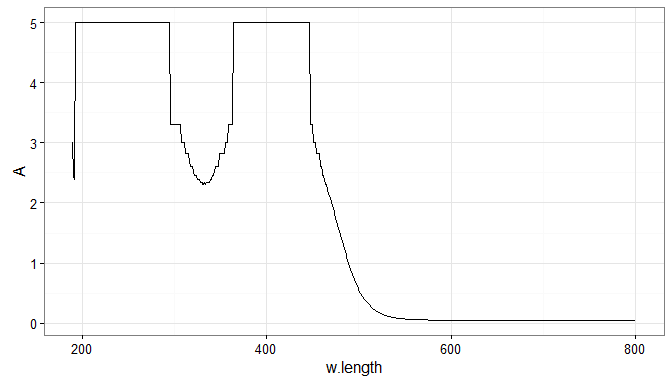

```r
ggplot(yellow_gel.spct, plot.qty = "absorbance") + geom_line()
```

The names of the additional parameters are consistent with those by method `plot()` in this package and in the now deprecated package `photobiologygg`.

## Stats

Several `ggplot` stats are defined by this package. All of them target light spectra, as they expect $x$ to represent wavelengths expressed in nanometres. However, they should behave correctly as long as this is true, with any `ggplot` object, based on any data format acceptable to `ggplot`. The name of the original variable is irrelevant, and it is the user responsibility to supply the correct variables through `aes()`. Of course, when using the spectral classes defined in package `photobiology` the defaults easy this task.

### Peaks and valleys

These stats do not fit peaks, simply search for local maxima and local minima in the data as supplied. The stats set several aesthetics based on calculated values. Not all of these are used by the default geom, make using other geoms easy. Furthermore text labels are formatted with `sptintf()` and these two stats accept format definitions through parameter `label.fmt`. Both the $x$ and $y$ values at the maxima or minima are returned. The stats use internally function `photobiology::find_peaks()` and arguments are passed down to it.

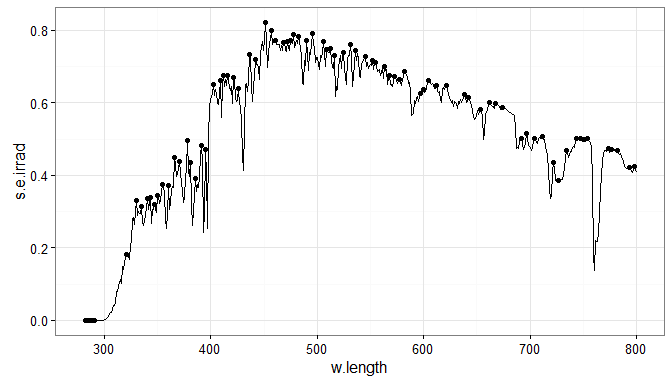

```r
ggplot(sun.spct) + geom_line() + stat_peaks()
```

Because of the conversion, the location of maxima and minima when an spectrum is expressed in photon and energy based units may differ. This is expected and not a bug.

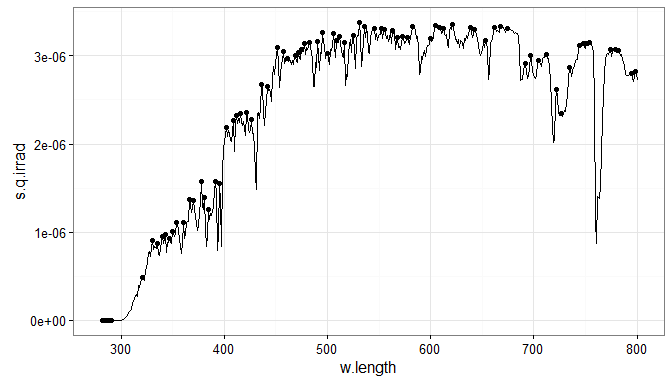

```r
ggplot(sun.spct, unit.out = "photon") + geom_line() + stat_peaks()
```

The complement to `stat_peaks()` is `stat_valleys`.

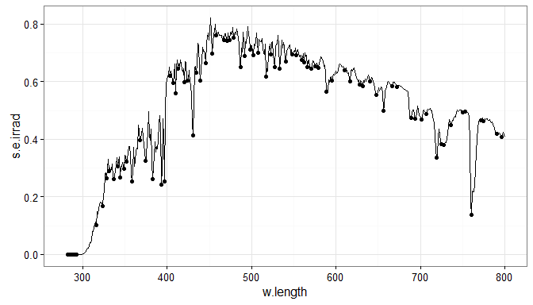

```r
ggplot(sun.spct) + geom_line() + stat_valleys()
```

One of the values calculated and mapped is the colour as seen by humans corresponding to the wavelength at the location of peaks and valleys. The colour is mapped to the `fill` aesthetic, so using a ‘filled’ shape results in a colourful plot. The *identity* scale is needed so that the correct colours are displayed using the colour definitions in the calculated data instead of a palette.

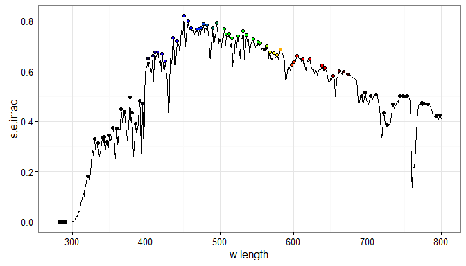

```r
ggplot(sun.spct) + geom_line() +
  stat_peaks(shape = 21) + scale_fill_identity()
```

We can use any of the aesthetics affecting the default *geom*, `"point"`.

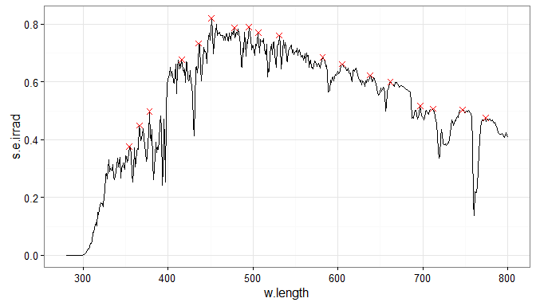

```r
ggplot(sun.spct) + geom_line() +
  stat_peaks(span = 21, shape = 4, color = "red", size = 2)
```

We can use several other *geoms* as needed, demonstrated here with *geom* `"text"`.

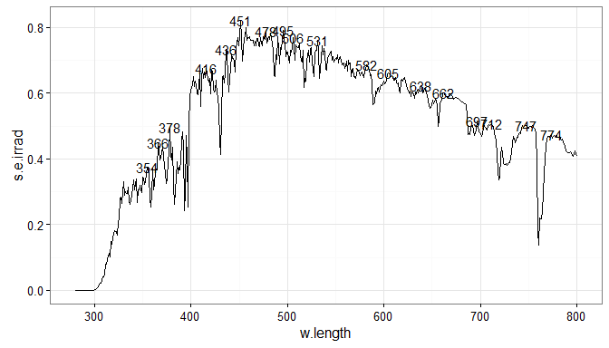

```r
ggplot(sun.spct) + geom_line() +
  stat_peaks(span = 21, geom = "text")
```

The same stat can be included more than once in the same plot, using different *geoms*. We here in addition demonstrate the use of several different parameters. The `span` argument determines the number of consecutive observations tested when searching for a local extreme, and it should be an odd integer number. In addition we here demonstrate the use of a *geom* new to `ggplot2` 2.0.0 called `"label"` which again results in colourful labels by default.

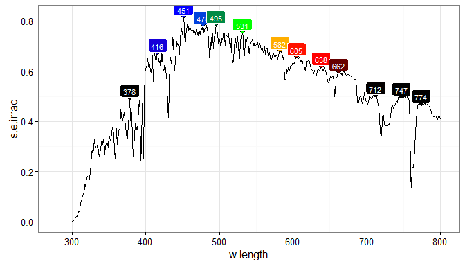

```r
ggplot(sun.spct) + geom_line() +
  stat_peaks(shape = 21, span = 25, size = 2) + scale_fill_identity() +
  stat_peaks(geom = "label", span = 25, vjust = "bottom", size = 3,
             color = "white")
```

Setting `span` to `NULL` results in the span set to the range of the data, and so in this case the stat returns the global extreme, instead of a local one. In this case we use geoms `"vline"` and `"hline"` taking advantage that suitable aesthetics are set by the stats.

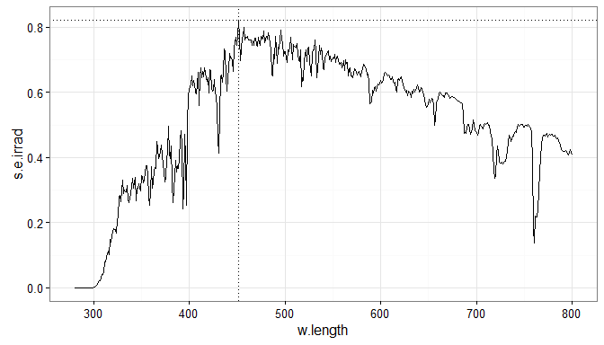

```r
ggplot(sun.spct) + geom_line() +
  stat_peaks(span = NULL, geom = "vline", linetype = "dotted") +
  stat_peaks(span = NULL, geom = "hline", linetype = "dotted")
```

By default the `label` aesthetic is mapped to a calculated label `..x.label..` giving the wavelength in nanometres. This mapping can be changed to give to a label giving the $y$-value at the peak.

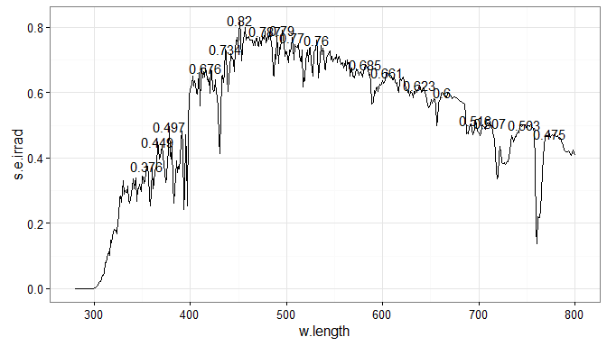

```r
ggplot(sun.spct) + geom_line() +
  stat_peaks(span = 21, geom = "text", aes(label = ..y.label..))
```

As *aesthetics* can use values computed on-the-fly we can even use `paste()` to map a label that combines both values and adds additional text.

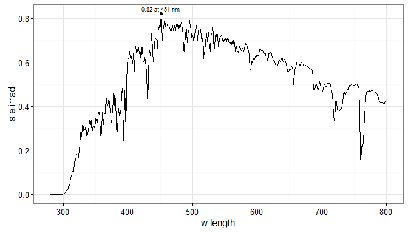

```r
ggplot(sun.spct) + geom_line() +
  stat_peaks(span = NULL) +
  stat_peaks(span = NULL, geom = "text", vjust = -0.5, size = 2.5,
             aes(label = paste(..y.label.., "at", ..x.label.. , "nm")))
```

Finally we demonstrate that both stats can be simultaneously used. One can also choose to use different spans as demonstrated here, resulting in more maxima being marked by points than labelled with text.

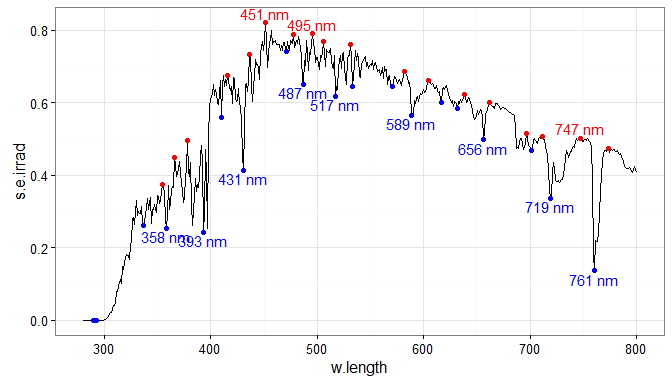

```r
ggplot(sun.spct) + geom_line() +
  stat_peaks(span = 21, geom = "point", colour = "red") +
  stat_valleys(span = 21, geom = "point", colour = "blue") +
  stat_peaks(span = 51, geom = "text", colour = "red",
             vjust = -0.3, label.fmt = "%3.0f nm") +
  stat_valleys(span = 51, geom = "text", colour = "blue",
               vjust = 1.2, label.fmt = "%3.0f nm")
```

This final example shows a few additional tricks used in the case to mark and label the maximum of the spectrum. This example also demonstrates why it is important that these are stats. The peaks are searched and labels generated once for each group, in this case each *facet*.

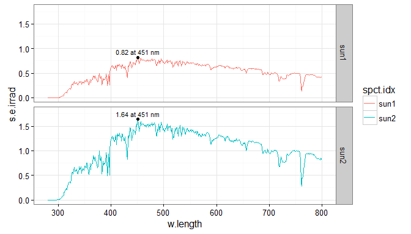

```r
ggplot(two_suns.spct) + aes(color = spct.idx) +
  geom_line() + ylim(NA, 1.8) +
  stat_peaks(span = NULL, color = "black") +
  stat_peaks(span = NULL, geom = "text", vjust = -0.5, size = 3,
             color = "black",
             aes(label = paste(..y.label.., "at", ..x.label.. , "nm"))) +
  facet_grid(spct.idx~.)
```

## Color from wavelength

This stat calculates the colour corresponding to each $x$-value (assumed expressed in nanometres) and adds it to the data. It does not summarize the data like `stat_summary()` nor does it subset the data like `stat_peaks`, consequently the plot does not require any additional *geom* to have all observations plotted. It sets both *color* and *fill* aesthetics to a suitable default.

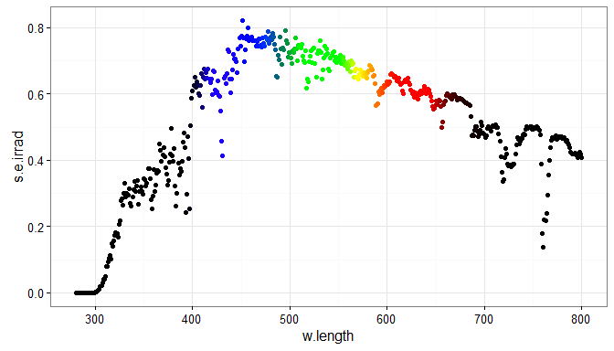

```r
ggplot(sun.spct) +
  stat_color() + scale_color_identity()
```

By use of a filled *shape* and adding a black border by overriding the default *color* aesthetic and over-plotting these point on top of a line, we obtain a better separation from the background.

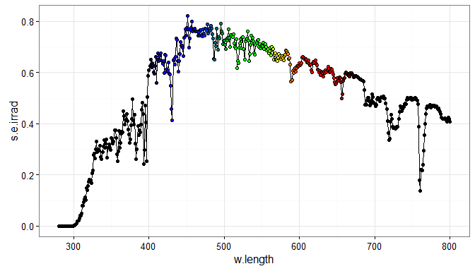

```r
ggplot(sun.spct) +
  geom_line() +
  stat_color(shape = 21, color = "black") +
  scale_fill_identity()
```

With a *trick* using many narrow *bars* we can fill the area under the line with a the calculated colours. This works satisfactorily as the data set has a small wavelength step, as in this case we are using a bar of uniform colour for each wavelength value in the data set.

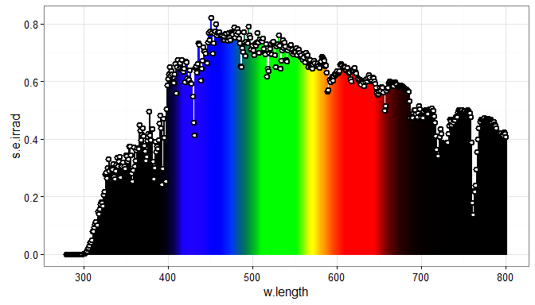

```r
ggplot(sun.spct) +
  stat_color(geom = "bar") +
  geom_point(shape = 21, color = "black", stroke = 1.2, fill = "white") +
  scale_fill_identity() +
  scale_color_identity() +
  theme_bw()
```

As final example we demonstrate a plot with *facets* and *shape* based groups.

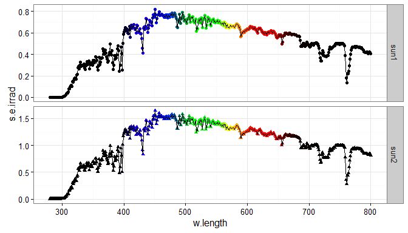

```r
ggplot(two_suns.spct) + aes(shape = spct.idx) +
  stat_color() + scale_color_identity() +
  geom_line() +
  facet_grid(spct.idx~., scales = "free_y")
```

## Averages and similar summaries

### Summaries by wavelength range

Our `stat_wl_summary()` is quite different to `ggplot2`s `stat_summary()`. One could criticize that it calculates summaries using a grouping that is not based on a *ggplot* *aesthetic*. This is a deviation from the grammar of graphics but allows the calculation of summaries for an arbitrary region of the range of $x$-values in the spectral data.

The summary is calculated for a range of wavelengths, and the `range` argument defaults to the range of wavelengths in each group defined by other aesthetics. The default *geom* is `"text"`.

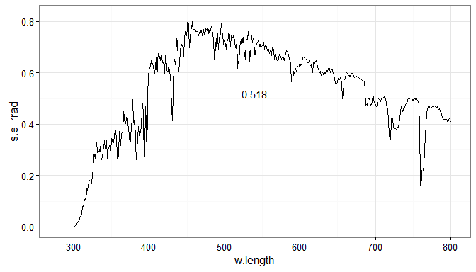

```r
ggplot(sun.spct) + geom_line() + stat_wl_summary()
```

We can optionally supply an argument for `range` to limit the summary to a certain part of the spectrum, in which case the use of the default `"text"` *geom* is misleading. We add the line last so that it is drawn on top of the rectangle.

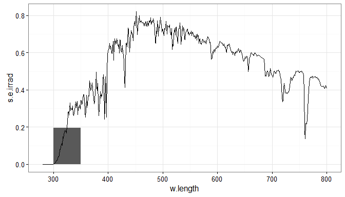

```r
ggplot(sun.spct) +
  stat_wl_summary(range = c(300,350), geom = "rect") +
  geom_line()
```

Here we show how to add horizontal line and label for the overall mean, by adding the same stat twice, using different values for `geom`.

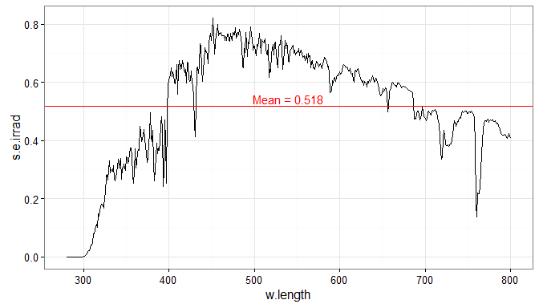

```r
ggplot(sun.spct) +
  geom_line() +
  stat_wl_summary(geom = "hline", color = "red") +
  stat_wl_summary(label.fmt = "Mean = %.3g", color = "red", vjust = -0.3)
```

Or we can add the *aesthetic* twice with two different geoms to get the value plotted as a rectangular area and the value as formatted text. We use `vjust` to move the text above the end of the bar, instead of it being centred on the value itself.

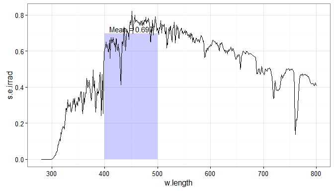

```r
ggplot(sun.spct) +
  stat_wl_summary(range = c(400,500), geom = "rect", alpha = 0.2, fill = color(450)) +
  stat_wl_summary(range = c(400,500), label.fmt = "Mean = %.3g", vjust = -0.3, geom = "text") +
  geom_line()
```

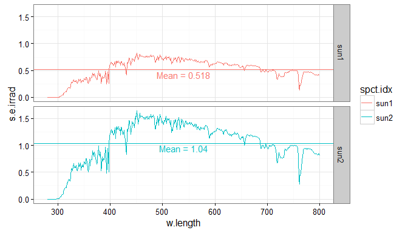

```r
ggplot(two_suns.spct) + aes(color = spct.idx) +
  geom_line() +
  stat_wl_summary(geom = "hline") +
  stat_wl_summary(label.fmt = "Mean = %.3g", vjust = 1.2, show.legend = FALSE) +
  facet_grid(spct.idx~.)
```

Same example as above but using a free scale for $y$, still working as expected.

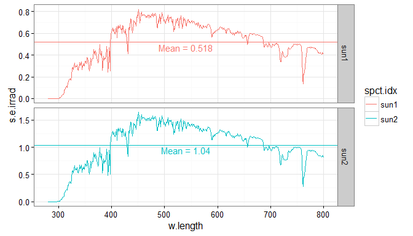

```r
ggplot(two_suns.spct) + aes(color = spct.idx) +
  geom_line() +
  stat_wl_summary(geom = "hline") +
  stat_wl_summary(label.fmt = "Mean = %.3g", vjust = 1.2, show.legend = FALSE) +
  facet_grid(spct.idx~., scales = "free_y")
```

### Means by waveband

Our `stat_wb_mean()` is quite different to `ggplot2`s `stat_summary()`. One could criticize that it calculates summaries using a grouping that is not based on a *ggplot* *aesthetic*. This is a deviation from the grammar of graphics but allows the calculation of summaries for an arbitrary waveband of the spectrum based on `photobiology::waveband` objects, or lists of such objects. In contrast to `stat_wl_summary()` this allows the use of several ranges, and also of different weighting functions. This function returns both mean and total values for each waveband. It differes from `stat_wb_total()` only in the default *aesthetics* set.

The first example uses a `waveband` object created on-the-fly and defining a range of wavelengths.

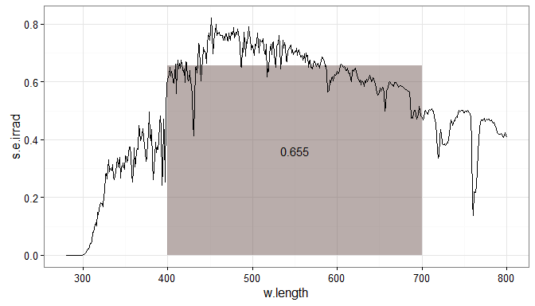

```r
ggplot(sun.spct) +
  stat_wb_mean(w.band = PAR(), geom = "rect", alpha = 0.5) +
  stat_wb_mean(w.band = PAR(), geom = "text") +
  geom_line() +
  scale_color_identity() +
  scale_fill_identity() +
  theme_bw()
```

If a numeric vector or a spectrum is supplied as argument to `waveband`, its range is calculated and used to construct a temporary `waveband` object.

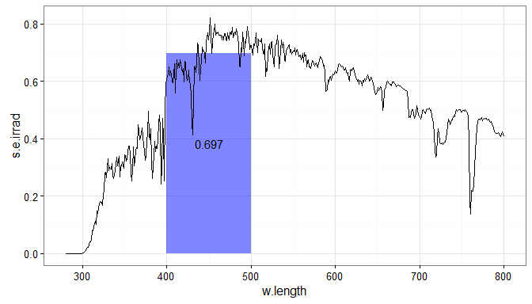

```r
ggplot(sun.spct) +
  stat_wb_mean(w.band = c(400,500), geom = "rect", alpha = 0.5) +
  stat_wb_mean(w.band = c(400,500), geom = "text") +
  geom_line() +
  scale_color_identity() +
  scale_fill_identity() +
  theme_bw()
```

Lists of wavebands, either user-defined or as in this case using constructor defined in package `photobiologyWavebands` can be also used.

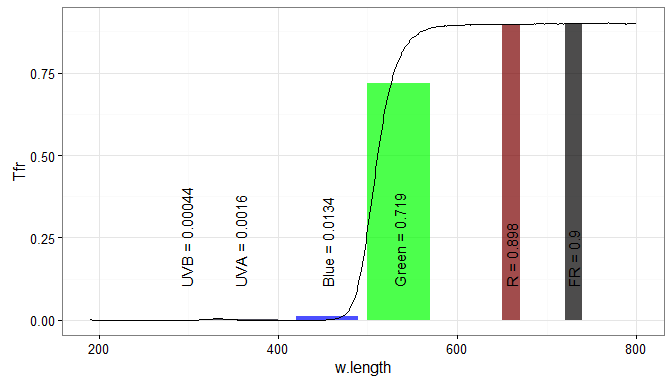

```r
ggplot(yellow_gel.spct) +
  stat_wb_mean(w.band = Plant_bands(), geom = "rect", alpha = 0.7) +
  stat_wb_mean(w.band = Plant_bands(), angle = 90, hjust = 0, geom = "text", ypos.fixed = 0.1,
                 aes(label = paste(..wb.name.., " = ", ..y.label.., sep = ""))) +
  geom_line() +
  scale_fill_identity() +
  theme_bw()
```